# **섹션 1: 단백질 언어 모델 소개**

# **다운스트림 태스크를 위한 언어 모델 임베딩 전이 학습**

##[홈페이지로 돌아가기](https://github.com/Graylab/DL4Proteins-notebooks)

이 코드와 튜토리얼은 RosettaCon 2024의 Sergey Ovchinnikov의 강연과 [노트북](https://colab.research.google.com/github/sokrypton/roscon2024/blob/main/finetune_esm2.ipynb)을 각색했습니다.

**목표: 이 워크숍을 마치면 다음을 수행할 수 있습니다:** * 사전 학습된 단백질 언어 모델 미세조정(finetuning)의 이점 설명하기 * LoRA(Low Rank Adaptation)를 사용하여 모델 미세조정하기 * 실제 작업에 미세조정 적용하기: 리간드 결합 부위 예측

*작업 내용을 저장하려면 이 노트북의 사본을 개인 Google 드라이브에 저장하세요.*

## **목차:**

#### **[섹션 1: 단백질 언어 모델 소개](https://colab.research.google.com/drive/1u8OhKlsm_pcuB2vYWSR8JXQELY0YfDgq#scrollTo=-11Vix19zlyJ)**

- [소개: 왜 미세조정인가?](https://colab.research.google.com/drive/1u8OhKlsm_pcuB2vYWSR8JXQELY0YfDgq#scrollTo=-11Vix19zlyJ)

#### **[섹션 2: ESM 직접 미세조정](https://colab.research.google.com/drive/1u8OhKlsm_pcuB2vYWSR8JXQELY0YfDgq#scrollTo=SgNiijAzzlyL)**

- [직접 미세조정: ESM 시각화](https://colab.research.google.com/drive/1u8OhKlsm_pcuB2vYWSR8JXQELY0YfDgq#scrollTo=t_0WYotopJE6)
- [직접 미세조정: 학습](https://colab.research.google.com/drive/1u8OhKlsm_pcuB2vYWSR8JXQELY0YfDgq#scrollTo=q1xg8blxzlyL)

#### **[섹션 3: Low-Rank Adaptor ESM 미세조정](https://colab.research.google.com/drive/1u8OhKlsm_pcuB2vYWSR8JXQELY0YfDgq#scrollTo=0oo3HdqUzlyL)**

- [LoRA: ESM에 LoRA 부착하기](https://colab.research.google.com/drive/1u8OhKlsm_pcuB2vYWSR8JXQELY0YfDgq#scrollTo=VRxQNb1WzlyM&line=1&uniqifier=1)
- [LoRA: LoRA란 무엇인가?](https://colab.research.google.com/drive/1u8OhKlsm_pcuB2vYWSR8JXQELY0YfDgq#scrollTo=83TEKjw9ted-)
- [LoRA: LoRA로 학습하기](https://colab.research.google.com/drive/1u8OhKlsm_pcuB2vYWSR8JXQELY0YfDgq#scrollTo=ESNXggJVtZre)

대규모 단백질 서열 데이터셋에 대해 학습된 단백질 언어 모델은 단백질 구조와 기능을 이해하고 예측하는 능력을 혁신적으로 변화시켰습니다. 이러한 사전 학습된 모델은 단백질 서열의 일반적인 패턴을 포착하지만, 특정 작업에 맞게 조정해야 하는 경우가 많습니다. 이 과정을 미세조정(finetuning)이라고 합니다.

## **왜 미세조정인가?**

1. 작업 특이성(Task Specificity): 사전 학습된 모델은 단백질 서열에 대한 일반적인 이해를 제공하지만 특정 작업에는 더 집중적인 지식이 필요할 수 있습니다.
2. 제한된 데이터: 많은 단백질 관련 작업에는 레이블이 지정된 데이터가 제한적입니다. 미세조정을 통해 특정 작업에 적응하면서 사전 학습된 모델의 지식을 활용할 수 있습니다.
3. 효율성: 사전 학습된 모델에서 시작하는 것이 처음부터 학습하는 것보다 종종 더 빠르고 효과적입니다.

그러나 미세조정에는 고유한 과제가 있습니다. 대규모 모델의 모든 파라미터를 미세조정하는 것은 계산 비용이 많이 들 수 있으며, 여전히 데이터셋 크기에 제한을 받습니다. 제한된 작업별 데이터로 전체 미세조정을 수행하면 과적합(overfitting)이 발생할 수 있으며, 모델이 특정 작업에 적응하는 동안 일반적인 지식을 잃을 수 있습니다.

```python
#@markdown <font color='#e59454'>Question Time! Run to Show Question
from IPython.display import HTML, display
from ipywidgets import widgets

def create_answer_box(question, correct_answer):
    def display_answer(button):
        user_answer = text_area.value.strip()
        result.value = f"<pre class='answer-text'><b>{correct_answer}</b></pre>"

    text_area = widgets.Textarea(
        placeholder='Enter your answer here...',
        layout={'width': '95%', 'height': '100px'}
    )
    submit_button = widgets.Button(description="Submit")
    result = widgets.HTML(value="")

    vbox = widgets.VBox([text_area, submit_button, result])
    submit_button.on_click(display_answer)

    display(HTML(f"<b>{question}</b>"))
    display(vbox)
    display(HTML("""
    <style>
    .widget-html-content {
        width: 95%;
        white-space: normal;
        word-wrap: break-word;
    }
    .answer-text {
        width: 90%;
        color: green;
        line-height: 1.5;
        white-space: pre-wrap;
        word-wrap: break-word;
        font-family: inherit;
        font-size: inherit;
        margin: 0;
        padding: 0;
    }
    </style>
    """))

# Example usage
create_answer_box('What might be an example where finetuning is useful',
                  'Any application with limited data would benefit from finetuning, as it allows us to use transfer learning from more general data.')
```

**What might be an example where finetuning is useful**

# **섹션 2: ESM 직접 미세조정**

미세조정의 중요한 응용 분야 중 하나는 단백질의 어떤 위치가 리간드와 상호 작용할 수 있는지 예측하는 것입니다. 이 정보는 단백질 기능을 이해하고 신약을 설계하는 데 매우 중요합니다.

이 특정 작업의 경우 ESM 임베딩을 사용하여 각 잔기가 리간드와 결합하는지 여부의 확률을 결정합니다. 레이블이 지정된 결합 포켓이 있는 단백질 세트에서 ESM을 간단히 튜닝합니다.

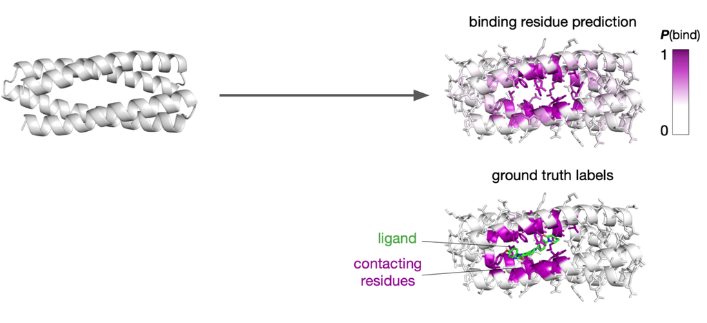

```python
#@markdown Let's set up our environment and load the necessary libraries. Take a peak at the code if you are interested in learning how to import large language models using the HuggingFace transformers library!
model_name = "esm2_t6_8M_UR50D" # @param ["esm2_t33_650M_UR50D", "esm2_t30_150M_UR50D", "esm2_t12_35M_UR50D", "esm2_t6_8M_UR50D"]
import os
import matplotlib.pyplot as plt
import numpy as np
import torch
import torch.nn as nn
import torch.optim as optim
from torch.utils.data import DataLoader, TensorDataset
from transformers import EsmForSequenceClassification, EsmForTokenClassification, AutoTokenizer

trainable_params = lambda x: sum(p.numel() for p in x.parameters() if p.requires_grad)


DEVICE = torch.device('cuda:0' if torch.cuda.is_available() else 'cpu')

model = EsmForTokenClassification.from_pretrained(f"facebook/{model_name}",
                                                  num_labels=1,
                                                  hidden_dropout_prob=0.15)

tokenizer = AutoTokenizer.from_pretrained(f"facebook/{model_name}")
model = model.to(DEVICE)
```

```
Some weights of EsmForTokenClassification were not initialized from the model checkpoint at facebook/esm2_t6_8M_UR50D and are newly initialized: ['classifier.bias', 'classifier.weight']
You should probably TRAIN this model on a down-stream task to be able to use it for predictions and inference.
```

```python
#@markdown Let's take a look at our model and how many parameters we are training
print(f'NUMBER OF TRAINABLE PARAMETERS: {trainable_params(model)}')
print('\nModel Information\n----------------------------')
model
```

```
NUMBER OF TRAINABLE PARAMETERS: 7737722

Model Information
----------------------------
```

```
EsmForTokenClassification(
  (esm): EsmModel(
    (embeddings): EsmEmbeddings(
      (word_embeddings): Embedding(33, 320, padding_idx=1)
      (dropout): Dropout(p=0.15, inplace=False)
      (position_embeddings): Embedding(1026, 320, padding_idx=1)
    )
    (encoder): EsmEncoder(
      (layer): ModuleList(
        (0-5): 6 x EsmLayer(
          (attention): EsmAttention(
            (self): EsmSelfAttention(
              (query): Linear(in_features=320, out_features=320, bias=True)
              (key): Linear(in_features=320, out_features=320, bias=True)
              (value): Linear(in_features=320, out_features=320, bias=True)
              (dropout): Dropout(p=0.0, inplace=False)
              (rotary_embeddings): RotaryEmbedding()
            )
            (output): EsmSelfOutput(
              (dense): Linear(in_features=320, out_features=320, bias=True)
              (dropout): Dropout(p=0.15, inplace=False)
            )
            (LayerNorm): LayerNorm((320,), eps=1e-05, elementwise_affine=True)
          )
          (intermediate): EsmIntermediate(
            (dense): Linear(in_features=320, out_features=1280, bias=True)
          )
          (output): EsmOutput(
            (dense): Linear(in_features=1280, out_features=320, bias=True)
            (dropout): Dropout(p=0.15, inplace=False)
          )
          (LayerNorm): LayerNorm((320,), eps=1e-05, elementwise_affine=True)
        )
      )
      (emb_layer_norm_after): LayerNorm((320,), eps=1e-05, elementwise_affine=True)
    )
    (contact_head): EsmContactPredictionHead(
      (regression): Linear(in_features=120, out_features=1, bias=True)
      (activation): Sigmoid()
    )
  )
  (dropout): Dropout(p=0.15, inplace=False)
  (classifier): Linear(in_features=320, out_features=1, bias=True)
)
```

## **Raw 미세조정**

여기서는 대규모 언어 모델(ESM2)을 가져와 리간드 접촉 예측을 위해 튜닝할 추가 레이어를 추가했습니다. 단백질 언어 모델의 모든 파라미터를 직접 미세조정하는 순진한 접근 방식을 시도해 봅시다. 모델이 학습됨에 따라 이 방법의 한계에 대해 생각해 보세요.

```python
%matplotlib inline
from IPython.display import display, clear_output
#@markdown Run training!!!

# GET DATA
batch_size = 32
max_crop_len = 512

!wget -qnc https://github.com/sokrypton/roscon2024/raw/main/af2bind_data_0.pkl
import pickle
with open("af2bind_data_0.pkl", "rb") as handle:
  DATA = pickle.load(handle)

import numpy as np
import pickle
import torch
from torch.utils.data import DataLoader, Dataset, TensorDataset

# Helper function to pad sequences
def pad_sequence(seq, max_len, pad_value=0):
    pad_size = max(0, max_len - len(seq))
    return np.pad(seq, (0, pad_size), 'constant', constant_values=pad_value)[:max_len]

class CustomProteinDataset(Dataset):
    def __init__(self, inputs, attention_masks, outputs, masks, max_crop_len=128):
        self.inputs = inputs
        self.attention_masks = attention_masks
        self.outputs = outputs
        self.masks = masks
        self.max_crop_len = max_crop_len

    def __len__(self):
        return len(self.inputs)

    def __getitem__(self, idx):
        input_ids = self.inputs[idx]
        attention_mask = self.attention_masks[idx]
        output = self.outputs[idx]
        mask = self.masks[idx]

        # Calculate the true length of the sequence (where attention_mask == 1)
        true_len = int(np.sum(attention_mask))

        # Determine the crop length (if the true length is less than max_crop_len, use true_len)
        crop_len = min(self.max_crop_len, true_len)

        # Randomly sample a crop starting index
        if true_len > crop_len:
            start_idx = np.random.randint(0, true_len - crop_len + 1)
        else:
            start_idx = 0

        # Crop the sequences
        input_ids = input_ids[start_idx:start_idx + crop_len]
        attention_mask = attention_mask[start_idx:start_idx + crop_len].astype(np.float32)
        output = output[start_idx:start_idx + crop_len].astype(np.float32)
        mask = mask[start_idx:start_idx + crop_len].astype(np.float32)

        # Pad the cropped sequences to max_crop_len
        input_ids = pad_sequence(input_ids, self.max_crop_len)
        attention_mask = pad_sequence(attention_mask, self.max_crop_len)
        output = pad_sequence(output, self.max_crop_len)
        mask = pad_sequence(mask, self.max_crop_len)

        return torch.tensor(input_ids), torch.tensor(attention_mask), torch.tensor(output), torch.tensor(mask)

# Create DataLoaders
dataloaders = []
for v in range(3):  # train/test/validation
    dataset = CustomProteinDataset(DATA["inputs"][v], DATA["attention_masks"][v],
                                   DATA["outputs"][v], DATA["masks"][v],
                                   max_crop_len=max_crop_len)
    dataloader = DataLoader(dataset, batch_size=batch_size, shuffle=(v == 0))
    dataloaders.append(dataloader)


# Training Code

def compute_loss(logits, labels, mask):
  """Compute masked loss."""
  loss = nn.BCEWithLogitsLoss(reduction='none')(logits, labels)
  masked_loss = loss * mask
  mean_loss = masked_loss.sum() / mask.sum()
  return mean_loss

def train_one_epoch(model, dataloader, optimizer):
  """Train the model for one epoch."""
  model.train()
  total_loss = 0

  for batch in dataloader:
    inputs_batch, attention_masks_batch, true_labels_batch, mask_batch = [x.to(DEVICE) for x in batch]

    # Forward pass
    outputs = model(input_ids=inputs_batch, attention_mask=attention_masks_batch)
    logits = outputs.logits.squeeze(-1)

    # Compute loss
    mean_loss = compute_loss(logits, true_labels_batch, mask_batch)

    # Backward pass and optimization
    optimizer.zero_grad()
    mean_loss.backward()
    optimizer.step()

    total_loss += mean_loss.item()

  average_loss = total_loss / len(dataloader)
  return average_loss

def validate(model, dataloader):
    """Validate the model."""
    model.eval()
    total_loss = 0

    with torch.no_grad():
      for batch in dataloader:
        inputs_batch, attention_masks_batch, true_labels_batch, mask_batch = [x.to(DEVICE) for x in batch]

        # Forward pass
        outputs = model(input_ids=inputs_batch, attention_mask=attention_masks_batch)
        logits = outputs.logits.squeeze(-1)

        # Compute loss
        mean_loss = compute_loss(logits, true_labels_batch, mask_batch)

        total_loss += mean_loss.item()

    average_loss = total_loss / len(dataloader)
    return average_loss



# Training loop
def train_model(model, train_dataloader, test_dataloader, num_epochs, optimizer):
    """Train and validate the model."""
    epoch_plot = []
    train_plot = []
    test_plot = []
    for epoch in range(num_epochs):
        train_loss = train_one_epoch(model, train_dataloader, optimizer)
        test_loss = validate(model, test_dataloader)
        #print(f"Epoch {epoch+1}/{num_epochs}, Train Loss: {train_loss:.4f}, Test Loss: {test_loss:.4f}")
        # clear matplotlib plot if already exists
        plt.clf()
        clear_output(wait=True)
        # visualize with matplotlib
        epoch_plot.append(epoch + 1)
        train_plot.append(train_loss)
        test_plot.append(test_loss)
        plt.plot(epoch_plot, train_plot, 'b.-', label='Train')
        plt.plot(epoch_plot, test_plot, 'r.-', label='Test')
        plt.xlabel('Epoch')
        plt.ylabel('Loss (Lower is Better)')
        plt.title('Training and Validation Loss')
        # Set ticks
        plt.yticks([])
        plt.xlim(1, num_epochs)
        plt.xticks(range(1, num_epochs+1))
        plt.legend()
        plt.show()

    print("Training complete.")

# Actually run training
learning_rate = 1e-3 # @param {"type":"number"}
optimizer = optim.Adam(model.parameters(), lr=learning_rate)
num_epochs = 20  # @param {"type":"integer"}
train_model(model, dataloaders[0], dataloaders[1], num_epochs, optimizer)
```

[figure not shown]

```
Training complete.
```

```python
#@markdown <font color='#e59454'>Question Time! Run to Show Question
from IPython.display import HTML, display
from ipywidgets import widgets

def create_answer_box(question, correct_answer):
    def display_answer(button):
        user_answer = text_area.value.strip()
        result.value = f"<pre class='answer-text'><b>{correct_answer}</b></pre>"

    text_area = widgets.Textarea(
        placeholder='Enter your answer here...',
        layout={'width': '95%', 'height': '100px'}
    )
    submit_button = widgets.Button(description="Submit")
    result = widgets.HTML(value="")

    vbox = widgets.VBox([text_area, submit_button, result])
    submit_button.on_click(display_answer)

    display(HTML(f"<b>{question}</b>"))
    display(vbox)
    display(HTML("""
    <style>
    .widget-html-content {
        width: 95%;
        white-space: normal;
        word-wrap: break-word;
    }
    .answer-text {
        width: 90%;
        color: green;
        line-height: 1.5;
        white-space: pre-wrap;
        word-wrap: break-word;
        font-family: inherit;
        font-size: inherit;
        margin: 0;
        padding: 0;
    }
    </style>
    """))

# Example usage
create_answer_box('Why might directly finetuning be suboptimal?',
                  '1. Training is slow since we need to train lots of parameters\n2. Direct finetuning leads to overfitting when working with smaller datasets.')
```

**Why might directly finetuning be suboptimal?**

# **섹션 3: Low Rank Adaptor (LoRA) ESM 미세조정**

LoRA는 대규모 모델 미세조정과 관련된 많은 문제를 해결하는 효율적인 미세조정 기술입니다. 의존성을 다시 설정해 봅시다. 그러나 모델과 훈련 가능한 파라미터를 살펴보면 뭔가 다릅니다. 무슨 일이 일어났는지 알 수 있나요?

```python
#@markdown Set up dependencies (Re-run for each time you run the training below)

# https://github.com/huggingface/peft
!pip -q install --no-dependencies peft
from peft import LoraConfig, get_peft_model, TaskType
model = EsmForTokenClassification.from_pretrained(f"facebook/{model_name}",
                                                  num_labels=1,
                                                  hidden_dropout_prob=0.15)

tokenizer = AutoTokenizer.from_pretrained(f"facebook/{model_name}")
model = model.to(DEVICE)

config = LoraConfig(
    task_type=TaskType.SEQ_CLS,
    target_modules=["query", "key", "value"],
    r=4,
    lora_dropout=0.15,
)
model = get_peft_model(model, config)
```

```
Some weights of EsmForTokenClassification were not initialized from the model checkpoint at facebook/esm2_t6_8M_UR50D and are newly initialized: ['classifier.bias', 'classifier.weight']
You should probably TRAIN this model on a down-stream task to be able to use it for predictions and inference.
```

```python
#@markdown Show trainable parameters and model
print(f'NUMBER OF TRAINABLE PARAMETERS: {trainable_params(model)}')
print('\nModel Information\n----------------------------')
model
```

```
NUMBER OF TRAINABLE PARAMETERS: 46401

Model Information
----------------------------
```

```
PeftModelForSequenceClassification(
  (base_model): LoraModel(
    (model): EsmForTokenClassification(
      (esm): EsmModel(
        (embeddings): EsmEmbeddings(
          (word_embeddings): Embedding(33, 320, padding_idx=1)
          (dropout): Dropout(p=0.15, inplace=False)
          (position_embeddings): Embedding(1026, 320, padding_idx=1)
        )
        (encoder): EsmEncoder(
          (layer): ModuleList(
            (0-5): 6 x EsmLayer(
              (attention): EsmAttention(
                (self): EsmSelfAttention(
                  (query): lora.Linear(
                    (base_layer): Linear(in_features=320, out_features=320, bias=True)
                    (lora_dropout): ModuleDict(
                      (default): Dropout(p=0.15, inplace=False)
                    )
                    (lora_A): ModuleDict(
                      (default): Linear(in_features=320, out_features=4, bias=False)
                    )
                    (lora_B): ModuleDict(
                      (default): Linear(in_features=4, out_features=320, bias=False)
                    )
                    (lora_embedding_A): ParameterDict()
                    (lora_embedding_B): ParameterDict()
                    (lora_magnitude_vector): ModuleDict()
                  )
                  (key): lora.Linear(
                    (base_layer): Linear(in_features=320, out_features=320, bias=True)
                    (lora_dropout): ModuleDict(
                      (default): Dropout(p=0.15, inplace=False)
                    )
                    (lora_A): ModuleDict(
                      (default): Linear(in_features=320, out_features=4, bias=False)
                    )
                    (lora_B): ModuleDict(
                      (default): Linear(in_features=4, out_features=320, bias=False)
                    )
```

[output cut: 40 more lines]

```
        (contact_head): EsmContactPredictionHead(
          (regression): Linear(in_features=120, out_features=1, bias=True)
          (activation): Sigmoid()
        )
      )
      (dropout): Dropout(p=0.15, inplace=False)
      (classifier): ModulesToSaveWrapper(
        (original_module): Linear(in_features=320, out_features=1, bias=True)
        (modules_to_save): ModuleDict(
          (default): Linear(in_features=320, out_features=1, bias=True)
        )
      )
    )
  )
)
```

```python
#@markdown <font color='#e59454'>Question Time! Run to Show Question

import random
from IPython.display import display, HTML

def create_quiz(question, correct_answers, decoy_answers):
    # Combine the correct answers with the decoy answers
    answers = correct_answers + decoy_answers
    # Shuffle the answers
    random.shuffle(answers)

    # Generate the HTML code
    html_code = f""" <div style="font-family: Arial, sans-serif; margin: 30px; max-width: 1000px;">
    <h3 style="word-wrap: break-word;">{question}</h3>"""

    # Add each answer as a checkbox
    for i, answer in enumerate(answers):
        html_code += f"""
        <div style="word-wrap: break-word; margin-bottom: 10px;">
        <input type="checkbox" id="option{i}" name="quiz" value="{answer}">
        <label for="option{i}" id="label{i}">{answer}</label>
        </div>"""

    # Add the submit button and feedback section
    html_code += f"""
    <button onclick="checkAnswers()">Submit</button>
    <p id="feedback" style="font-weight: bold;"></p>
    </div>
    <script>
    function checkAnswers() {{
        var checkboxes = document.getElementsByName('quiz');
        var correctAnswers = {str(correct_answers)};
        var feedback = document.getElementById('feedback');
        var numCorrect = 0;

        // Check each answer
        for (var i = 0, length = checkboxes.length; i < length; i++) {{
            var checkbox = checkboxes[i];
            var label = document.getElementById('label' + i);

            if (correctAnswers.includes(checkbox.value)) {{
                if (checkbox.checked) {{
                  if (numCorrect >= 0) {{
                    numCorrect++;
                  }}
                    label.style.color = "green";
                }} else {{
                    //label.style.color = "red";
                }}
            }} else if (checkbox.checked) {{
                numCorrect = -9999;
                label.style.color = "red";
            }} else {{
                //label.style.color = "inherit";
            }}
        }}

        // Provide feedback
        if (numCorrect === {len(correct_answers)}) {{
            feedback.textContent = "Correct!";
            feedback.style.color = "green";
        }} else {{
            feedback.textContent = "Incorrect.";
            feedback.style.color = "red";
        }}
    }}
    </script>"""

    display(HTML(html_code))

# Example
question = "What is different? Select all the correct answers."
correct_answers = ["The model now has less trainable parameters", "The model has new connections at each layer", "The model has more parameters"]
decoy_answers = ["The model has become deeper (more layers)", "Nothing has changed about the model architecture"]
create_quiz(question, correct_answers, decoy_answers)
```

What is different? Select all the correct answers.

Nothing has changed about the model architecture

The model has new connections at each layer

The model now has less trainable parameters

The model has become deeper (more layers)

The model has more parameters

### **LoRA 작동 방식**

모든 모델 파라미터를 업데이트하는 대신 LoRA는 은닉층의 출력에 가중치를 다시 부여하여 더 큰 모델을 튜닝하기 위해 소수의 훈련 가능한 파라미터를 도입합니다. 이는 각 레이어(또는 사용자가 지정한 레이어)에 더 작은 추가 은닉 파라미터 세트를 추가하여 수행됩니다. 그러면 전체 모델이 고정(frozen)되고 추가 은닉 파라미터만 학습됩니다.

### **왜 LoRA인가**

어댑터(adaptor)를 학습시킴으로써 단일 GPU에서 거대한 모델을 학습시킬 수 있을 뿐만 아니라 어댑터의 ’병목(bottleneck)’을 조정하여 과적합을 방지할 수 있습니다.

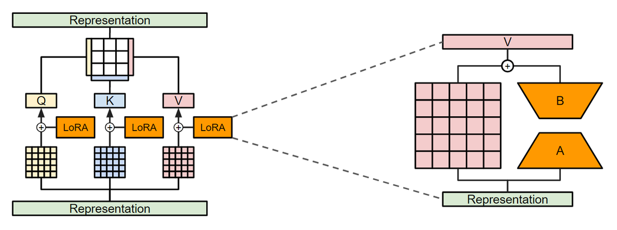

```python
%matplotlib inline
#@markdown We can directly run training using the same code as before, now that we have added LoRA adaptors to our model!
learning_rate = 1e-3 # @param {"type":"number"}
optimizer = optim.Adam(model.parameters(), lr=learning_rate)
num_epochs = 20  # @param {"type":"integer"}
train_model(model, dataloaders[0], dataloaders[1], num_epochs, optimizer)
```

[figure not shown]

```
Training complete.
```

```python
#@markdown <font color='#e59454'>Question Time! Run to Show Question
import random
from IPython.display import display, HTML

def create_quiz(question, correct_answer, decoy_answers):
    answers = [correct_answer] + decoy_answers
    random.shuffle(answers)

    html_code = f"""
    <div style="font-family: Arial, sans-serif; margin: 30px; max-width: 1000px;">
      <h3 style="word-wrap: break-word;">{question}</h3>
    """

    for i, answer in enumerate(answers):
        html_code += f"""
        <div style="word-wrap: break-word; margin-bottom: 10px;">
          <input type="radio" id="option{i}" name="quiz" value="{answer}">
          <label for="option{i}" id="label{i}">{answer}</label>
        </div>
        """

    html_code += f"""
      <button onclick="checkAnswer()">Submit</button>
      <p id="feedback" style="font-weight: bold;"></p>
    </div>
    <script>
    function checkAnswer() {{
        var radios = document.getElementsByName('quiz');
        var correctAnswer = "{correct_answer}";
        var feedback = document.getElementById('feedback');
        var selectedOption = null;
        var selectedLabel = null;

        for (var i = 0, length = radios.length; i < length; i++) {{
            if (radios[i].checked) {{
                selectedOption = radios[i].value;
                selectedLabel = document.getElementById('label' + i);
                break;
            }}
        }}

        if (selectedOption) {{
            if (selectedOption === correctAnswer) {{
                feedback.textContent = "Correct!";
                feedback.style.color = "green";
                selectedLabel.style.color = "green";
            }} else {{
                feedback.textContent = "Incorrect.";
                feedback.style.color = "red";
                selectedLabel.style.color = "red";
            }}
        }} else {{
            feedback.textContent = "Please select an answer.";
            feedback.style.color = "orange";
        }}
    }}
    </script>
    """
    display(HTML(html_code))

question = "How does LoRA help in finetuning large language models?"
correct_answer = "It reduces the number of trainable parameters, allowing for efficient finetuning on smaller datasets and preventing overfitting."
decoy_answers = [
    "It increases the model's capacity by adding more layers.",
    "It completely replaces the original model architecture.",
    "It only trains on new data, ignoring the pre-trained weights."
]
create_quiz(question, correct_answer, decoy_answers)
```

**순위가 너무 크면** 본질적으로 Raw 미세조정과 동일한 작업을 수행하게 됩니다. **너무 작으면** 파라미터가 충분히 변경될 수 없기 때문에 모델이 전혀 미세조정되지 않습니다.

다양한 값을 시도해보고 학습에 어떤 영향을 미치는지 확인해 보세요!

```python
%matplotlib inline
# Reloading model so that we don't have to re-run
model = EsmForTokenClassification.from_pretrained(f"facebook/{model_name}",
                                                  num_labels=1,
                                                  hidden_dropout_prob=0.15)

tokenizer = AutoTokenizer.from_pretrained(f"facebook/{model_name}")
model = model.to(DEVICE)

#@markdown Change rank and dropout
rank = 4 # @param {"type":"integer"}
dropout = 0.15 # @param {"type":"number"}

config = LoraConfig(
    task_type=TaskType.SEQ_CLS,
    target_modules=["query", "key", "value"],
    r=rank,
    lora_dropout=0.15,
)
model = get_peft_model(model, config)

#@markdown Training Parameters
learning_rate = 1e-3 # @param {"type":"number"}
optimizer = optim.Adam(model.parameters(), lr=learning_rate)
num_epochs = 20  # @param {"type":"integer"}
train_model(model, dataloaders[0], dataloaders[1], num_epochs, optimizer)
```

[output not shown]

## **결론**

이 노트북에서는 특정 작업을 위해 단백질 언어 모델을 미세조정하는 방법을 살펴보았습니다. 다음에 대해 배웠습니다: 1. 미세조정의 이점. 3. 미세조정 기술, 특히 Low Rank Adaptation (LoRA)에 중점을 둠. 4. 이러한 개념을 실제 작업에 적용: 리간드 결합 부위 예측.

이러한 강력한 모델과 효율적인 미세조정 기술을 활용하여 단백질 설계의 한계를 넓히고 약물 개발 및 효소 공학과 같은 분야의 발견을 가속화할 수 있습니다.

추가 탐구를 위해 다음을 고려해 보세요: - 다양한 모델 아키텍처와 크기, 특히 SaProt와 같은 구조 인식 언어 모델로 실험해 보세요! - 최상의 균형을 찾기 위해 LoRA 크기를 조정해 보세요. - 이러한 모델을 단백질-단백질 상호 작용 예측 또는 특정 기능을 가진 새로운 단백질 설계와 같은 다른 단백질 관련 작업에 적용해 보세요.

단백질 언어 모델 분야는 빠르게 발전하고 있으므로 계속 호기심을 갖고 배우세요!

# **섹션 4: 추천 읽기 자료**

관련 논문

- 데이터 효율적인 딥 러닝을 통한 Low-N 단백질 공학, Biswas et al., Nature Methods, 2021
- 대조 적합성 학습: 단백질 적합성 랜드스케이프의 Low-N 학습을 위한 단백질 언어 모델 재프로그래밍, Zhao et al., bioRxiv, 2024
- 단백질 언어 모델 미세 조정으로 다양한 작업의 예측 향상, Schmirler et al., Nature Communications, 2024
- SeqProFT: 서열 전용 단백질 속성 예측을 위한 LoRA 미세조정 적용, Zhang et al., arXiv, 2024